# Bar Plots in ggplot2

Week 1- Day 4 | Lesson 1

Jiaqi

# Introduction

Bar plots are one of the most common and effective ways to visualize categorical data. In ggplot2, we can create bar plots using `geom_bar()`, which is perfect for: - Showing counts of categorical variables - Comparing quantities across different groups - Displaying proportions or percentages - Visualizing summary statistics

# Basic Syntax

The basic structure for creating bar plots in ggplot2:

```r
# Let's look at the mtcars dataset first
head(mtcars)
```

```
##                    mpg cyl disp  hp drat    wt  qsec vs am gear carb
## Mazda RX4         21.0   6  160 110 3.90 2.620 16.46  0  1    4    4
## Mazda RX4 Wag     21.0   6  160 110 3.90 2.875 17.02  0  1    4    4
## Datsun 710        22.8   4  108  93 3.85 2.320 18.61  1  1    4    1
## Hornet 4 Drive    21.4   6  258 110 3.08 3.215 19.44  1  0    3    1
## Hornet Sportabout 18.7   8  360 175 3.15 3.440 17.02  0  0    3    2
## Valiant           18.1   6  225 105 2.76 3.460 20.22  1  0    3    1
```

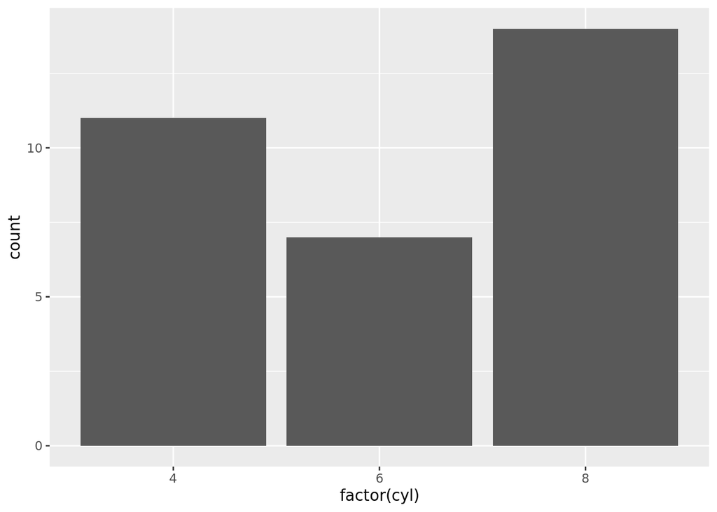

```r
# Basic bar plot syntax
ggplot(data = mtcars, aes(x = factor(cyl))) +
  geom_bar()
```

Key arguments for `geom_bar()`: - `stat`: “count” (default) or “identity” - `position`: “stack”, “dodge”, or “fill” - `width`: bar width (default = 0.9) - `fill`: color to fill the bars - `color`: color of bar borders

# Examples

##1. Basic Count Bar Plot

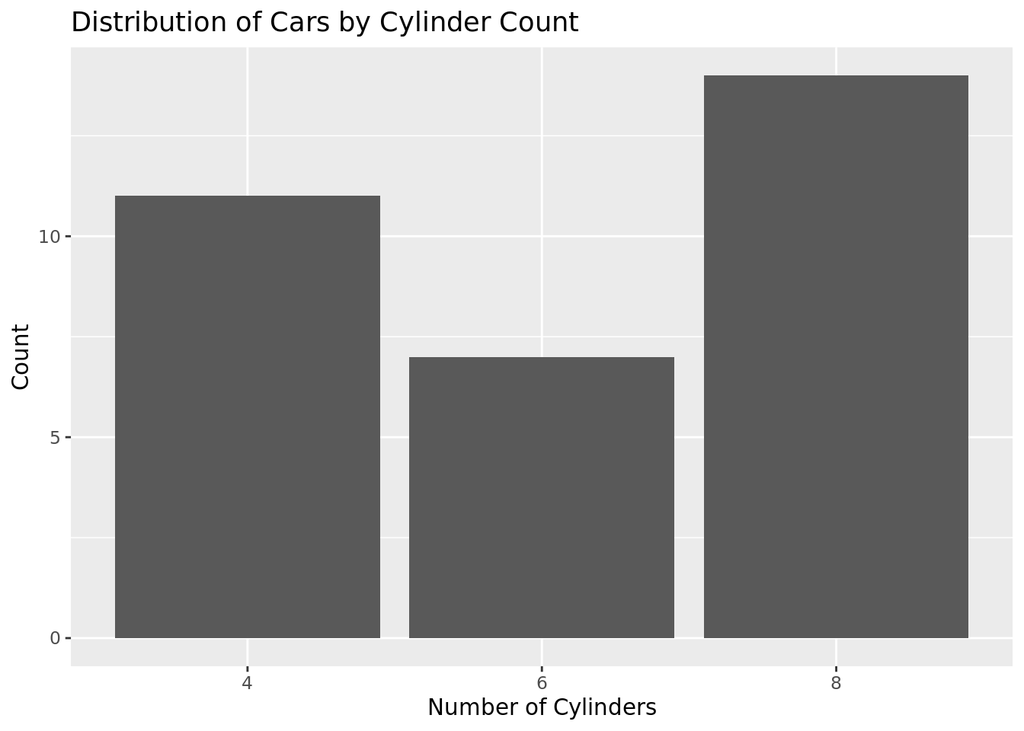

```r
# Simple bar plot of car cylinders
ggplot(mtcars, aes(x = factor(cyl))) +
  geom_bar() +
  labs(x = "Number of Cylinders",
       y = "Count",
       title = "Distribution of Cars by Cylinder Count")
```

## 2. Colored Bar Plot

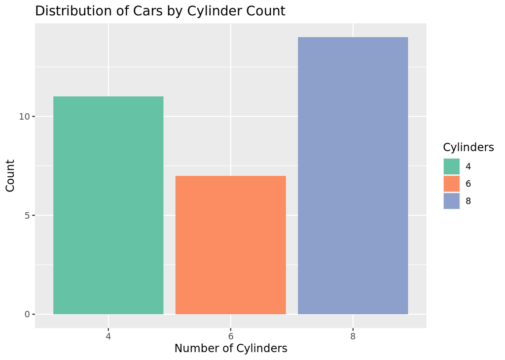

```r
# Adding color
ggplot(mtcars, aes(x = factor(cyl), fill = factor(cyl))) +
  geom_bar() +
  labs(x = "Number of Cylinders",
       y = "Count",
       title = "Distribution of Cars by Cylinder Count",
       fill = "Cylinders") +
  scale_fill_brewer(palette = "Set2")
```

## 3. Grouped Bar Plot

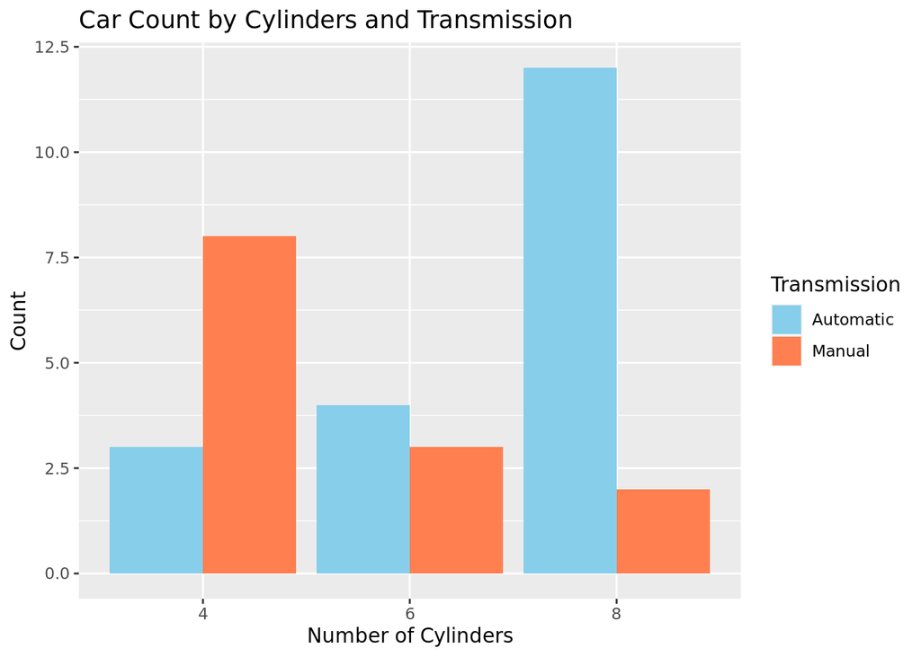

```r
# Creating grouped bars by transmission type
ggplot(mtcars, aes(x = factor(cyl), fill = factor(am))) +
  geom_bar(position = "dodge") +
  labs(x = "Number of Cylinders",
       y = "Count",
       title = "Car Count by Cylinders and Transmission",
       fill = "Transmission") +
  scale_fill_manual(values = c("skyblue", "coral"),
                    labels = c("Automatic", "Manual"))
```

# Practice Exercises

## Exercise 1: Basic Bar Plot

Let’s create a basic bar plot using the built-in `diamonds` dataset:

```r
# Load the diamonds dataset
data(diamonds)

# Look at the data structure
str(diamonds)
```

```
## tibble [53,940 × 10] (S3: tbl_df/tbl/data.frame)
##  $ carat  : num [1:53940] 0.23 0.21 0.23 0.29 0.31 0.24 0.24 0.26 0.22 0.23 ...
##  $ cut    : Ord.factor w/ 5 levels "Fair"<"Good"<..: 5 4 2 4 2 3 3 3 1 3 ...
##  $ color  : Ord.factor w/ 7 levels "D"<"E"<"F"<"G"<..: 2 2 2 6 7 7 6 5 2 5 ...
##  $ clarity: Ord.factor w/ 8 levels "I1"<"SI2"<"SI1"<..: 2 3 5 4 2 6 7 3 4 5 ...
##  $ depth  : num [1:53940] 61.5 59.8 56.9 62.4 63.3 62.8 62.3 61.9 65.1 59.4 ...
##  $ table  : num [1:53940] 55 61 65 58 58 57 57 55 61 61 ...
##  $ price  : int [1:53940] 326 326 327 334 335 336 336 337 337 338 ...
##  $ x      : num [1:53940] 3.95 3.89 4.05 4.2 4.34 3.94 3.95 4.07 3.87 4 ...
##  $ y      : num [1:53940] 3.98 3.84 4.07 4.23 4.35 3.96 3.98 4.11 3.78 4.05 ...
##  $ z      : num [1:53940] 2.43 2.31 2.31 2.63 2.75 2.48 2.47 2.53 2.49 2.39 ...
```

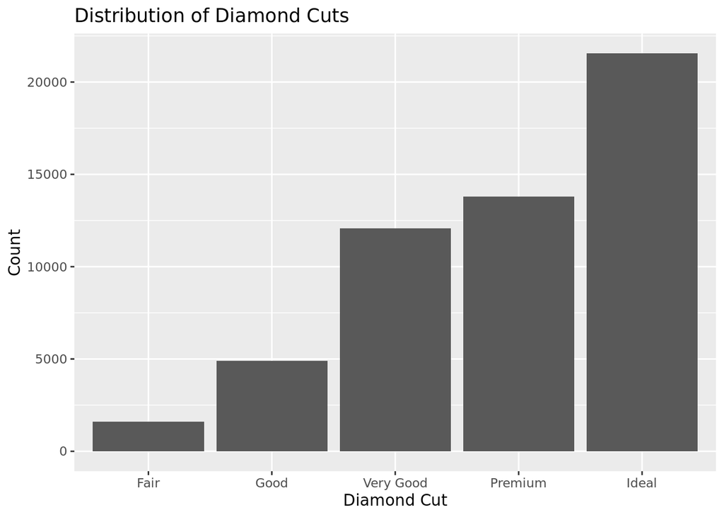

```r
# Create basic bar plot
ggplot(diamonds, aes(x = cut)) +
  geom_bar() +
  labs(x = "Diamond Cut",
       y = "Count",
       title = "Distribution of Diamond Cuts")
```

## Exercise 2: Customized Bar Plot

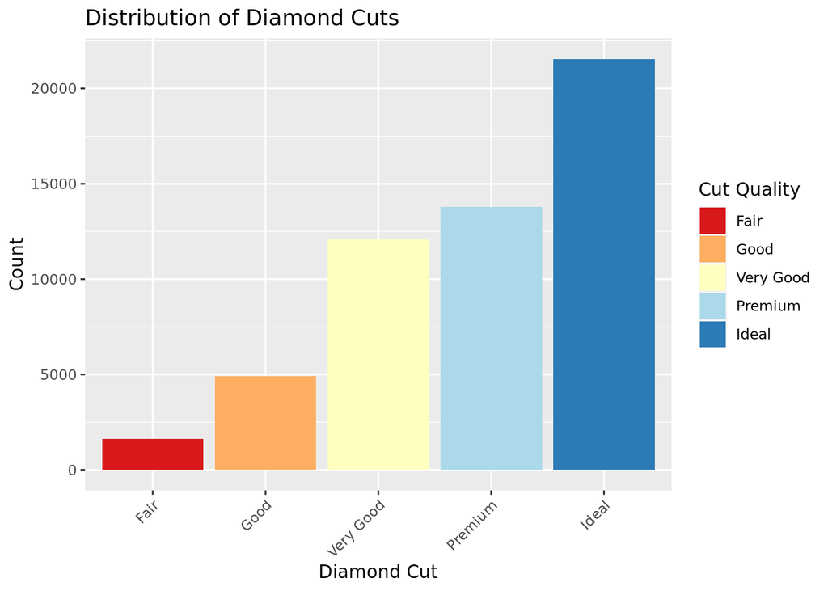

```r
ggplot(diamonds, aes(x = cut, fill = cut)) +
  geom_bar() +
  labs(x = "Diamond Cut",
       y = "Count",
       title = "Distribution of Diamond Cuts",
       fill = "Cut Quality") +
  scale_fill_brewer(palette = "RdYlBu") +
  theme(axis.text.x = element_text(angle = 45, hjust = 1))
```

## Exercise 3: Grouped Bar Plot

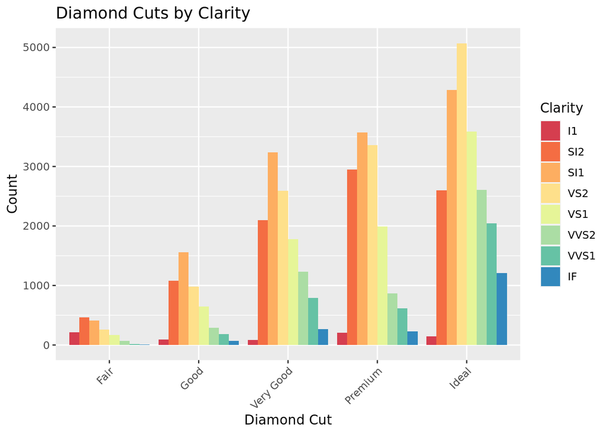

```r
ggplot(diamonds, aes(x = cut, fill = clarity)) +
  geom_bar(position = "dodge") +
  labs(x = "Diamond Cut",
       y = "Count",
       title = "Diamond Cuts by Clarity",
       fill = "Clarity") +
  scale_fill_brewer(palette = "Spectral") +
  theme(axis.text.x = element_text(angle = 45, hjust = 1))
```

# Challenge Task

Create a stacked percentage bar plot showing the proportion of clarity categories within each cut type:

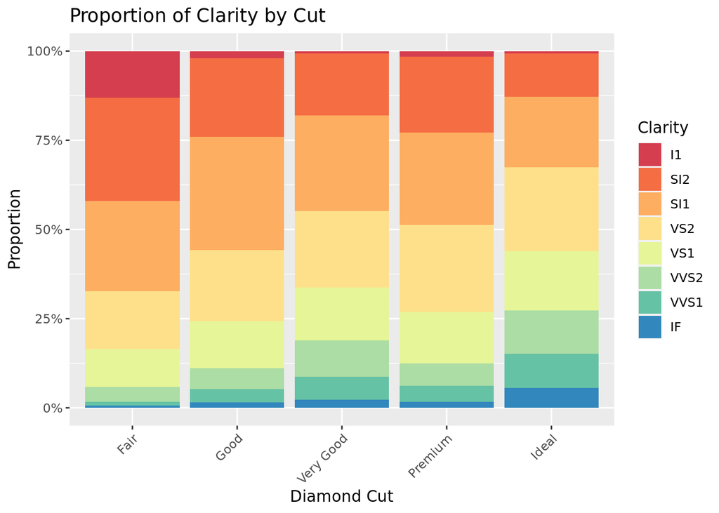

```r
ggplot(diamonds, aes(x = cut, fill = clarity)) +
  geom_bar(position = "fill") +
  labs(x = "Diamond Cut",
       y = "Proportion",
       title = "Proportion of Clarity by Cut",
       fill = "Clarity") +
  scale_fill_brewer(palette = "Spectral") +
  theme(axis.text.x = element_text(angle = 45, hjust = 1)) +
  scale_y_continuous(labels = scales::percent)
```

# Your Turn!

Now it’s your turn to practice. Try these exercises:

1. Create a bar plot of diamond colors
2. Make a grouped bar plot showing diamond color and cut
3. Create a proportional stacked bar plot of your choice using the diamonds dataset

Here’s a template to start with:

```r
# Exercise 1: Bar plot of diamond colors
ggplot(diamonds, aes(x = color)) +
  geom_bar()

# Add your customizations here!
```

# Tips for Success

1. Always start with a basic plot and build up complexity gradually
2. Test different color palettes to find what works best
3. Pay attention to readability of labels and legends
4. Consider your audience when adding customizations
5. Practice modifying the examples provided

# Resources

- [ggplot2 documentation](https://ggplot2.tidyverse.org/)
- [R Graph Gallery - Bar Plots](https://www.r-graph-gallery.com/barplot.html)

Need help or clarification with any of these concepts? Feel free to ask questions!